# Pretransplant natural antibody levels identify a subset of deceased donor kidney transplant recipients that benefit from infliximab induction

# 4 Data - models-relevant

## 4.1 Define the model-relevant data

Note that eGFR based on the central measurement (`GFR_MDRD`) will be used for imputation, as it shows stronger correlations with variables containing missing values than either the combined local and central eGFR (`GFR_MDRD_2`) or the combined version with values set to 10 in cases of graft failure within the 2-year follow-up (`GFR_MDRD_3`)

**Open code**

```r
data_model_priorImpute <- data3 %>%
  dplyr::select(

    # outcomes
    DGF, infection_any, GFR_MDRD, GFR_MDRD_2, GFR_MDRD_3, BKV_event_2,

    # antigens
    GPL_BC_log2,
    MPL_BC_log2,
    GPE_dep_log2,
    GPE_ind_log2,
    MPE_dep_log2,
    MPE_ind_log2,

    # other covariates
    male_sex,
    HLA_MM,
    male_sex_donor,
    KDPI,
    perfusion_event,
    CIT,
    infliximab,
    rec_age,

    # variables for imputation only
    HLAMMGE3,
    BKV_viremia_time,
    race_2,
    race_donor_2,
    age_donor,
    CMV_IgG_rec,
    de_novo_DSA,
    donor_type
  ) %>%
  filter(!is.na(GFR_MDRD_2),
         !is.na(GPE_dep_log2),
         !is.na(MPE_dep_log2))

data_model_priorImpute %>% summary()
##       DGF        infection_any       GFR_MDRD        GFR_MDRD_2
##  Min.   :0.000   Min.   :0.0000   Min.   :  8.44   Min.   :  4.30
##  1st Qu.:0.000   1st Qu.:0.0000   1st Qu.: 39.07   1st Qu.: 38.10
##  Median :0.000   Median :0.0000   Median : 49.88   Median : 49.90
##  Mean   :0.339   Mean   :0.4237   Mean   : 51.90   Mean   : 52.04
##  3rd Qu.:1.000   3rd Qu.:1.0000   3rd Qu.: 64.98   3rd Qu.: 64.98
##  Max.   :1.000   Max.   :1.0000   Max.   :123.48   Max.   :123.48
##
##    GFR_MDRD_3      BKV_event_2      GPL_BC_log2       MPL_BC_log2
##  Min.   :  4.30   Min.   :0.0000   Min.   :-3.8616   Min.   :-5.533
##  1st Qu.: 38.10   1st Qu.:0.0000   1st Qu.:-0.7449   1st Qu.: 1.093
##  Median : 49.90   Median :0.0000   Median :-0.1046   Median : 2.043
##  Mean   : 51.72   Mean   :0.2147   Mean   : 0.1147   Mean   : 1.996
##  3rd Qu.: 64.98   3rd Qu.:0.0000   3rd Qu.: 0.8505   3rd Qu.: 2.942
##  Max.   :123.48   Max.   :1.0000   Max.   : 4.9498   Max.   : 5.417
##
##   GPE_dep_log2      GPE_ind_log2       MPE_dep_log2       MPE_ind_log2
##  Min.   :-3.6439   Min.   :-3.86775   Min.   :-3.60823   Min.   :-3.8997
##  1st Qu.:-2.6666   1st Qu.:-3.41120   1st Qu.:-2.92686   1st Qu.:-3.4501
##  Median :-2.3921   Median :-3.16488   Median :-2.45799   Median :-3.1520
##  Mean   :-2.2821   Mean   :-2.92303   Mean   :-2.40099   Mean   :-3.0307
##  3rd Qu.:-2.0058   3rd Qu.:-2.70840   3rd Qu.:-1.99712   3rd Qu.:-2.7037
##  Max.   : 0.4163   Max.   :-0.03283   Max.   : 0.05866   Max.   :-0.5724
##
##     male_sex          HLA_MM      male_sex_donor        KDPI
##  Min.   :0.0000   Min.   :0.000   Min.   :0.0000   Min.   :20.00
##  1st Qu.:0.0000   1st Qu.:4.000   1st Qu.:0.0000   1st Qu.:37.00
##  Median :1.0000   Median :5.000   Median :1.0000   Median :53.00
##  Mean   :0.6158   Mean   :4.373   Mean   :0.5537   Mean   :53.77
##  3rd Qu.:1.0000   3rd Qu.:5.000   3rd Qu.:1.0000   3rd Qu.:71.00
##  Max.   :1.0000   Max.   :6.000   Max.   :1.0000   Max.   :93.00
##                   NA's   :35
##  perfusion_event       CIT           infliximab        rec_age
##  Min.   :0.0000   Min.   : 3.267   Min.   :0.0000   Min.   :27.00
##  1st Qu.:0.0000   1st Qu.:10.267   1st Qu.:0.0000   1st Qu.:45.00
##  Median :0.0000   Median :15.325   Median :0.0000   Median :54.00
##  Mean   :0.4038   Mean   :15.920   Mean   :0.4915   Mean   :53.15
##  3rd Qu.:1.0000   3rd Qu.:20.508   3rd Qu.:1.0000   3rd Qu.:61.00
##  Max.   :1.0000   Max.   :50.133   Max.   :1.0000   Max.   :73.00
##  NA's   :21       NA's   :3
##     HLAMMGE3      BKV_viremia_time     race_2        race_donor_2
##  Min.   :0.0000   Min.   :  22.0   Min.   :0.0000   Min.   :0.0000
##  1st Qu.:1.0000   1st Qu.: 196.0   1st Qu.:0.0000   1st Qu.:0.0000
##  Median :1.0000   Median : 735.0   Median :0.0000   Median :1.0000
##  Mean   :0.8475   Mean   : 693.9   Mean   :0.4068   Mean   :0.6158
##  3rd Qu.:1.0000   3rd Qu.: 952.0   3rd Qu.:1.0000   3rd Qu.:1.0000
##  Max.   :1.0000   Max.   :1854.0   Max.   :1.0000   Max.   :1.0000
##
##    age_donor      CMV_IgG_rec     de_novo_DSA        donor_type
##  Min.   : 4.00   Min.   :0.000   Min.   :0.00000   Min.   :0.0000
##  1st Qu.:31.75   1st Qu.:0.000   1st Qu.:0.00000   1st Qu.:1.0000
##  Median :42.50   Median :1.000   Median :0.00000   Median :1.0000
##  Mean   :40.33   Mean   :0.661   Mean   :0.06215   Mean   :0.7514
##  3rd Qu.:50.00   3rd Qu.:1.000   3rd Qu.:0.00000   3rd Qu.:1.0000
##  Max.   :69.00   Max.   :1.000   Max.   :1.00000   Max.   :1.0000
##  NA's   :1

## Get mean values
mmale_sex <- mean(data_model_priorImpute$male_sex, na.rm = TRUE)
mmale_sex_donor <- mean(data_model_priorImpute$male_sex_donor, na.rm = TRUE)
mperfusion_event <- mean(data_model_priorImpute$perfusion_event, na.rm = TRUE)
mrec_age <- mean(data_model_priorImpute$rec_age, na.rm = TRUE)
mKDPI <- mean(data_model_priorImpute$KDPI, na.rm = TRUE)
mCIT <- mean(data_model_priorImpute$CIT, na.rm = TRUE)
mHLA_MM <- mean(data_model_priorImpute$HLA_MM, na.rm = TRUE)
mDGF <- mean(data_model_priorImpute$DGF, na.rm = TRUE)
```

## 4.2 Explore data

**Open code**

```r
skim(data_model_priorImpute)
```

Data summary

| Name | data_model_priorImpute |
| --- | --- |
| Number of rows | 177 |
| Number of columns | 28 |
| _______________________ |  |
| Column type frequency: |  |
| numeric | 28 |
| ________________________ |  |
| Group variables | None |

**Variable type: numeric**

| skim_variable | n_missing | complete_rate | mean | sd | p0 | p25 | p50 | p75 | p100 | hist |
| --- | --- | --- | --- | --- | --- | --- | --- | --- | --- | --- |
| DGF | 0 | 1.00 | 0.34 | 0.47 | 0.00 | 0.00 | 0.00 | 1.00 | 1.00 | ▇▁▁▁▅ |
| infection_any | 0 | 1.00 | 0.42 | 0.50 | 0.00 | 0.00 | 0.00 | 1.00 | 1.00 | ▇▁▁▁▆ |
| GFR_MDRD | 0 | 1.00 | 51.90 | 20.26 | 8.44 | 39.07 | 49.88 | 64.98 | 123.48 | ▃▇▆▂▁ |
| GFR_MDRD_2 | 0 | 1.00 | 52.04 | 20.66 | 4.30 | 38.10 | 49.90 | 64.98 | 123.48 | ▂▇▇▂▁ |
| GFR_MDRD_3 | 0 | 1.00 | 51.72 | 21.17 | 4.30 | 38.10 | 49.90 | 64.98 | 123.48 | ▂▇▇▂▁ |
| BKV_event_2 | 0 | 1.00 | 0.21 | 0.41 | 0.00 | 0.00 | 0.00 | 0.00 | 1.00 | ▇▁▁▁▂ |
| GPL_BC_log2 | 0 | 1.00 | 0.11 | 1.42 | -3.86 | -0.74 | -0.10 | 0.85 | 4.95 | ▁▇▇▃▁ |
| MPL_BC_log2 | 0 | 1.00 | 2.00 | 1.56 | -5.53 | 1.09 | 2.04 | 2.94 | 5.42 | ▁▁▃▇▃ |
| GPE_dep_log2 | 0 | 1.00 | -2.28 | 0.65 | -3.64 | -2.67 | -2.39 | -2.01 | 0.42 | ▂▇▂▁▁ |
| GPE_ind_log2 | 0 | 1.00 | -2.92 | 0.73 | -3.87 | -3.41 | -3.16 | -2.71 | -0.03 | ▇▅▁▁▁ |
| MPE_dep_log2 | 0 | 1.00 | -2.40 | 0.67 | -3.61 | -2.93 | -2.46 | -2.00 | 0.06 | ▆▇▆▁▁ |
| MPE_ind_log2 | 0 | 1.00 | -3.03 | 0.57 | -3.90 | -3.45 | -3.15 | -2.70 | -0.57 | ▇▇▃▁▁ |
| male_sex | 0 | 1.00 | 0.62 | 0.49 | 0.00 | 0.00 | 1.00 | 1.00 | 1.00 | ▅▁▁▁▇ |
| HLA_MM | 35 | 0.80 | 4.37 | 1.45 | 0.00 | 4.00 | 5.00 | 5.00 | 6.00 | ▁▁▂▃▇ |
| male_sex_donor | 0 | 1.00 | 0.55 | 0.50 | 0.00 | 0.00 | 1.00 | 1.00 | 1.00 | ▆▁▁▁▇ |
| KDPI | 0 | 1.00 | 53.77 | 20.60 | 20.00 | 37.00 | 53.00 | 71.00 | 93.00 | ▇▇▆▆▅ |
| perfusion_event | 21 | 0.88 | 0.40 | 0.49 | 0.00 | 0.00 | 0.00 | 1.00 | 1.00 | ▇▁▁▁▆ |
| CIT | 3 | 0.98 | 15.92 | 7.14 | 3.27 | 10.27 | 15.32 | 20.51 | 50.13 | ▆▇▃▁▁ |
| infliximab | 0 | 1.00 | 0.49 | 0.50 | 0.00 | 0.00 | 0.00 | 1.00 | 1.00 | ▇▁▁▁▇ |
| rec_age | 0 | 1.00 | 53.15 | 10.49 | 27.00 | 45.00 | 54.00 | 61.00 | 73.00 | ▂▅▆▇▅ |
| HLAMMGE3 | 0 | 1.00 | 0.85 | 0.36 | 0.00 | 1.00 | 1.00 | 1.00 | 1.00 | ▂▁▁▁▇ |
| BKV_viremia_time | 0 | 1.00 | 693.92 | 471.35 | 22.00 | 196.00 | 735.00 | 952.00 | 1854.00 | ▇▇▅▃▁ |
| race_2 | 0 | 1.00 | 0.41 | 0.49 | 0.00 | 0.00 | 0.00 | 1.00 | 1.00 | ▇▁▁▁▆ |
| race_donor_2 | 0 | 1.00 | 0.62 | 0.49 | 0.00 | 0.00 | 1.00 | 1.00 | 1.00 | ▅▁▁▁▇ |
| age_donor | 1 | 0.99 | 40.33 | 14.23 | 4.00 | 31.75 | 42.50 | 50.00 | 69.00 | ▂▃▇▇▃ |
| CMV_IgG_rec | 0 | 1.00 | 0.66 | 0.47 | 0.00 | 0.00 | 1.00 | 1.00 | 1.00 | ▅▁▁▁▇ |
| de_novo_DSA | 0 | 1.00 | 0.06 | 0.24 | 0.00 | 0.00 | 0.00 | 0.00 | 1.00 | ▇▁▁▁▁ |
| donor_type | 0 | 1.00 | 0.75 | 0.43 | 0.00 | 1.00 | 1.00 | 1.00 | 1.00 | ▂▁▁▁▇ |

## 4.3 Variables correlations

Is the missingness correlated with outcomes?

**Open code**

```r
df2_corr <- data_model_priorImpute %>% mutate(
  NA_perfusion_event = if_else(is.na(perfusion_event), 1, 0),
  NA_HLA_MM = if_else(is.na(HLA_MM), 1, 0)
)

m1 <- glm(NA_perfusion_event ~ DGF, family = 'binomial', data = df2_corr)
summary(m1)
##
## Call:
## glm(formula = NA_perfusion_event ~ DGF, family = "binomial",
##     data = df2_corr)
##
## Coefficients:
##             Estimate Std. Error z value         Pr(>|z|)
## (Intercept)  -1.9169     0.2765  -6.932 0.00000000000415 ***
## DGF          -0.2803     0.5115  -0.548            0.584
## ---
## Signif. codes:  0 '***' 0.001 '**' 0.01 '*' 0.05 '.' 0.1 ' ' 1
##
## (Dispersion parameter for binomial family taken to be 1)
##
##     Null deviance: 128.93  on 176  degrees of freedom
## Residual deviance: 128.62  on 175  degrees of freedom
## AIC: 132.62
##
## Number of Fisher Scoring iterations: 4

m2 <- glm(NA_perfusion_event ~ infection_any, family = 'binomial', data = df2_corr)
summary(m2)
##
## Call:
## glm(formula = NA_perfusion_event ~ infection_any, family = "binomial",
##     data = df2_corr)
##
## Coefficients:
##               Estimate Std. Error z value        Pr(>|z|)
## (Intercept)   -2.01490    0.30731  -6.556 0.0000000000551 ***
## infection_any  0.02247    0.46979   0.048           0.962
## ---
## Signif. codes:  0 '***' 0.001 '**' 0.01 '*' 0.05 '.' 0.1 ' ' 1
##
## (Dispersion parameter for binomial family taken to be 1)
##
##     Null deviance: 128.93  on 176  degrees of freedom
## Residual deviance: 128.93  on 175  degrees of freedom
## AIC: 132.93
##
## Number of Fisher Scoring iterations: 4

m3 <- glm(NA_perfusion_event ~ BKV_event_2, family = 'binomial', data = df2_corr)
summary(m2)
##
## Call:
## glm(formula = NA_perfusion_event ~ infection_any, family = "binomial",
##     data = df2_corr)
##
## Coefficients:
##               Estimate Std. Error z value        Pr(>|z|)
## (Intercept)   -2.01490    0.30731  -6.556 0.0000000000551 ***
## infection_any  0.02247    0.46979   0.048           0.962
## ---
## Signif. codes:  0 '***' 0.001 '**' 0.01 '*' 0.05 '.' 0.1 ' ' 1
##
## (Dispersion parameter for binomial family taken to be 1)
##
##     Null deviance: 128.93  on 176  degrees of freedom
## Residual deviance: 128.93  on 175  degrees of freedom
## AIC: 132.93
##
## Number of Fisher Scoring iterations: 4

m4 <- glm(NA_perfusion_event ~ GFR_MDRD_3, family = 'binomial', data = df2_corr)
summary(m4)
##
## Call:
## glm(formula = NA_perfusion_event ~ GFR_MDRD_3, family = "binomial",
##     data = df2_corr)
##
## Coefficients:
##              Estimate Std. Error z value Pr(>|z|)
## (Intercept) -1.770427   0.608599  -2.909  0.00363 **
## GFR_MDRD_3  -0.004611   0.011209  -0.411  0.68080
## ---
## Signif. codes:  0 '***' 0.001 '**' 0.01 '*' 0.05 '.' 0.1 ' ' 1
##
## (Dispersion parameter for binomial family taken to be 1)
##
##     Null deviance: 128.93  on 176  degrees of freedom
## Residual deviance: 128.76  on 175  degrees of freedom
## AIC: 132.76
##
## Number of Fisher Scoring iterations: 4

m5 <- glm(NA_perfusion_event ~ GFR_MDRD_2, family = 'binomial', data = df2_corr)
summary(m5)
##
## Call:
## glm(formula = NA_perfusion_event ~ GFR_MDRD_2, family = "binomial",
##     data = df2_corr)
##
## Coefficients:
##              Estimate Std. Error z value Pr(>|z|)
## (Intercept) -1.890831   0.629648  -3.003  0.00267 **
## GFR_MDRD_2  -0.002215   0.011400  -0.194  0.84592
## ---
## Signif. codes:  0 '***' 0.001 '**' 0.01 '*' 0.05 '.' 0.1 ' ' 1
##
## (Dispersion parameter for binomial family taken to be 1)
##
##     Null deviance: 128.93  on 176  degrees of freedom
## Residual deviance: 128.89  on 175  degrees of freedom
## AIC: 132.89
##
## Number of Fisher Scoring iterations: 4

m6 <- glm(NA_perfusion_event ~ GFR_MDRD, family = 'binomial', data = df2_corr)
summary(m6)
##
## Call:
## glm(formula = NA_perfusion_event ~ GFR_MDRD, family = "binomial",
##     data = df2_corr)
##
## Coefficients:
##              Estimate Std. Error z value Pr(>|z|)
## (Intercept) -2.533940   0.655266  -3.867  0.00011 ***
## GFR_MDRD     0.009888   0.011130   0.888  0.37433
## ---
## Signif. codes:  0 '***' 0.001 '**' 0.01 '*' 0.05 '.' 0.1 ' ' 1
##
## (Dispersion parameter for binomial family taken to be 1)
##
##     Null deviance: 128.93  on 176  degrees of freedom
## Residual deviance: 128.16  on 175  degrees of freedom
## AIC: 132.16
##
## Number of Fisher Scoring iterations: 4
```

How much are variables inter-correlated?

**Open code**

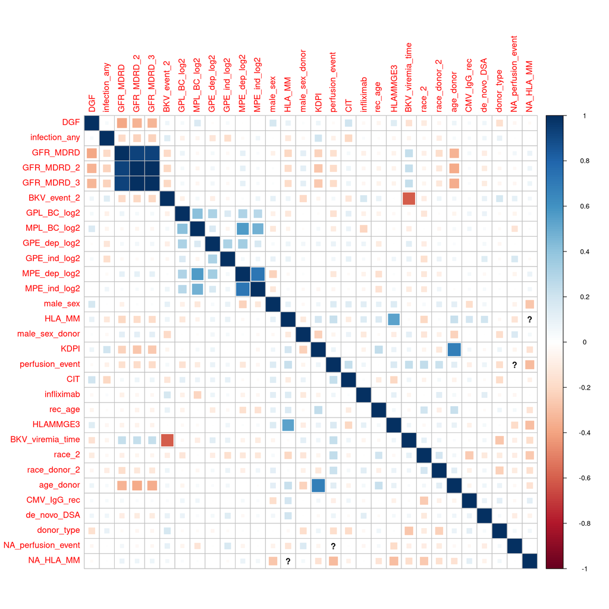

Figure 1: Spearman correlations between all variables, including transplant outcomes, natural antibody levels, and various clinical characteristics.

```r
corrplot(cor(df2_corr, use = "pairwise.complete.obs", method = 'spearman'),
         method = 'square')
## Warning in cor(df2_corr, use = "pairwise.complete.obs", method = "spearman"):
## the standard deviation is zero
## Warning in cor(df2_corr, use = "pairwise.complete.obs", method = "spearman"):
## the standard deviation is zero

path <- "gitignore/figures/sup_figure_1"

if (!file.exists(path)) {
  pdf(path, width = 12, height = 12)
  corrplot(cor(df2_corr, use = "pairwise.complete.obs", method = 'spearman'),
         method = 'square')
  dev.off()
}
```

## 4.4 Multiple imputation

**Open code**

```r
set.seed(2025)

data_model_priorImpute <- data_model_priorImpute %>%
  select(
    -c(GFR_MDRD_2, GFR_MDRD_3)
  )

init <- mice(data_model_priorImpute, maxit = 0)
init$method["perfusion_event"] <- "logreg"

data_imputed <- run(
  expr = mice(
    data_model_priorImpute,
    method = init$method,
    m = 80
  ),
  path = "gitignore/run/data_imputed"
)

## connect data not used for imputation (imputed clinically)
imp_list <- complete(data_imputed, action = "all")
mean(data3$GFR_MDRD == imp_list[[1]]$GFR_MDRD)
## [1] 1

imp_long <- complete(data_imputed, action = "long", include = TRUE)

imp_list <- map(imp_list, ~
                  bind_cols(
                    .x,
                    data3 %>% select(
                      terminated_days, graft_failure, death_event,
                      GFR_MDRD_2, GFR_MDRD_3, GFR_days_2
                      )
                    )
                )

imp_long <- imap_dfr(imp_list, ~
                       mutate(.x,
                              .imp = as.integer(.y),
                              .id  = row_number()
                              )
                     )

orig_stub <- data_model_priorImpute %>% mutate(.imp = 0, .id = row_number())
imp_long <- bind_rows(orig_stub, imp_long)

data_imputed <- as.mids(imp_long)

## Get the 1st imputed dataset
data_first <- complete(data_imputed, 'all')[1]$`1`

## update data prior imputation
data_model_priorImpute <- data_model_priorImpute %>%
  mutate(
    GFR_MDRD_3 = data3$GFR_MDRD_3,
    GFR_MDRD_2 = data3$GFR_MDRD_2
    )
```

### 4.4.1 Do we treat graft failure well?

We need to explore whether these with the graft failure within the 2-years period have clearly smaller eGFR

**Open code**

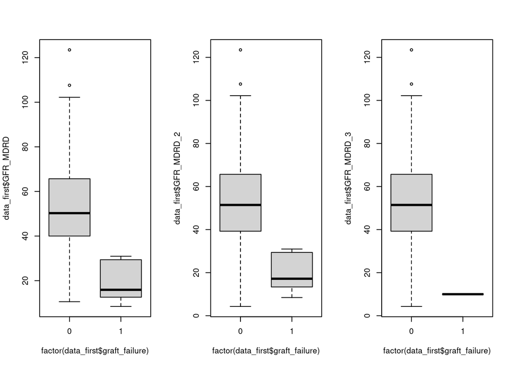

```r
par(mfrow = c(1, 3))

plot(data_first$GFR_MDRD ~ factor(data_first$graft_failure))
plot(data_first$GFR_MDRD_2 ~ factor(data_first$graft_failure))
plot(data_first$GFR_MDRD_3 ~ factor(data_first$graft_failure))
```

# 5 Data points of nAB levels

**Open code**

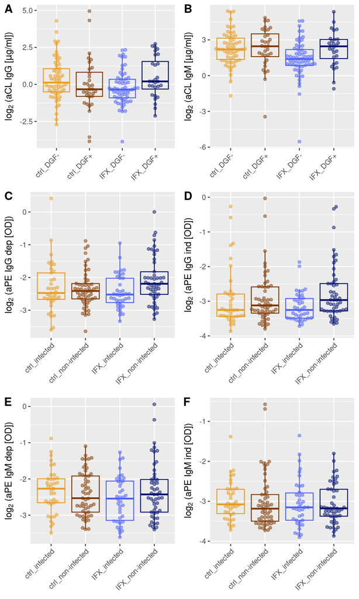

Figure 2: Distribution of natural antibody levels across groups defined by treatment (infliximab [IFX] vs. control [ctrl]) and key post-transplant outcomes: occurrence of peritransplant delayed graft function [DGF+ vs. DGF−; A to B] or post-transplant infection [“infected” vs. “non-infected”; C to F]. (**A**) Levels of anti-cardiolipin IgG. (**B**) Levels of anti-cardiolipin IgM. (**C**) Levels of co-factor-dependent anti-phosphatidylethanolamine IgG. (**D**) Levels of co-factor-independent anti-phosphatidylethanolamine IgG. (**E**) Levels of co-factor-dependent anti-phosphatidylethanolamine IgM. (**F**) Levels of co-factor-independent anti-phosphatidylethanolamine IgM.

```r
plotac <- "figure_1"
path <- "gitignore/figures"

 cole <- c(
   "#E89C20", "#803800",
   "#4C60FF", "#001070"
 )


 data_model_priorImpute <- data_model_priorImpute %>%
   mutate(
     group = factor(if_else(infliximab == 1, "infliximab", "control")),
     Group = case_when(
       infliximab == 1 & DGF == 0 ~ "IFX_DGF-",
       infliximab == 1 & DGF == 1 ~ "IFX_DGF+",
       infliximab == 0 & DGF == 0 ~ "ctrl_DGF-",
       infliximab == 0 & DGF == 1 ~ "ctrl_DGF+",
     )
   )

 p1 <- data_model_priorImpute %>%
   ggplot(aes(x = Group, y = GPL_BC_log2, color = Group)) +
   geom_boxplot(outlier.shape = NA, fill = NA, width = 0.8) +
   geom_beeswarm(alpha = 0.5, cex = 2.3, size = 1.4) +
   scale_color_manual(values = cole) +
   labs(
     y = expression(log[2] ~ "(aCL IgG [" * mu * "g/ml])"),
     x = NULL
   ) +
   theme(
     axis.text.x = element_text(angle = 45, hjust = 1),
     legend.position = "none"
   )

 p2 <- data_model_priorImpute %>%
   ggplot(aes(x = Group, y = MPL_BC_log2, color = Group)) +
   geom_boxplot(outlier.shape = NA, fill = NA, width = 0.8) +
   geom_beeswarm(alpha = 0.5, cex = 2.3, size = 1.4) +
   scale_color_manual(values = cole) +
   labs(
     y = expression(log[2] ~ "(aCL IgM [" * mu * "g/ml])"),
     x = NULL
   ) +
   theme(
     axis.text.x = element_text(angle = 45, hjust = 1),
     legend.position = "none"
   )


 data_model_priorImpute <- data_model_priorImpute %>%
   mutate(
     group = factor(if_else(infliximab == 1, "infliximab", "control")),
     Group = case_when(
       infliximab == 1 & infection_any == 0 ~ "IFX_non-infected",
       infliximab == 1 & infection_any == 1 ~ "IFX_infected",
       infliximab == 0 & infection_any == 0 ~ "ctrl_non-infected",
       infliximab == 0 & infection_any == 1 ~ "ctrl_infected",
     )
   )

 p3 <- data_model_priorImpute %>%
   ggplot(aes(x = Group, y = GPE_dep_log2, color = Group)) +
   geom_boxplot(outlier.shape = NA, fill = NA, width = 0.8) +
   geom_beeswarm(alpha = 0.5, cex = 2.3, size = 1.4) +
   scale_color_manual(values = cole) +
   # theme(axis.text.x = element_blank()) +
   labs(
     y = expression(log[2] ~ "(aPE IgG dep [OD])"),
     x = NULL
   ) +
   theme(
     axis.text.x = element_text(angle = 45, hjust = 1),
     legend.position = "none"
   )

 p4 <- data_model_priorImpute %>%
   ggplot(aes(x = Group, y = GPE_ind_log2, color = Group)) +
   geom_boxplot(outlier.shape = NA, fill = NA, width = 0.8) +
   geom_beeswarm(alpha = 0.5, cex = 2.3, size = 1.4) +
   scale_color_manual(values = cole) +
   # theme(axis.text.x = element_blank()) +
   labs(
     y = expression(log[2] ~ "(aPE IgG ind [OD])"),
     x = NULL
   ) +
   theme(
     axis.text.x = element_text(angle = 45, hjust = 1),
     legend.position = "none"
   )

 p5 <- data_model_priorImpute %>%
   ggplot(aes(x = Group, y = MPE_dep_log2, color = Group)) +
   geom_boxplot(outlier.shape = NA, fill = NA, width = 0.8) +
   geom_beeswarm(alpha = 0.5, cex = 2.3, size = 1.4) +
   scale_color_manual(values = cole) +
   # theme(axis.text.x = element_blank()) +
   labs(
     y = expression(log[2] ~ "(aPE IgM dep [OD])"),
     x = NULL
   ) +
   theme(
     axis.text.x = element_text(angle = 45, hjust = 1),
     legend.position = "none"
   )

 p6 <- data_model_priorImpute %>%
   ggplot(aes(x = Group, y = MPE_ind_log2, color = Group)) +
   geom_boxplot(outlier.shape = NA, fill = NA, width = 0.8) +
   geom_beeswarm(alpha = 0.5, cex = 2.3, size = 1.4) +
   scale_color_manual(values = cole) +
   # theme(axis.text.x = element_blank()) +
   labs(
     y = expression(log[2] ~ "(aPE IgM ind [OD])"),
     x = NULL
   ) +
   theme(
     axis.text.x = element_text(angle = 45, hjust = 1),
     legend.position = "none"
   )

   assign(
     plotac,
     cowplot::plot_grid(p1, p2, p3, p4, p5, p6,
       labels = c("A", "B", "C", "D", "E", "F"),
       ncol = 2, nrow = , rel_heights = c(1, 1.1, 1.1)
     )
   )

if (!file.exists(paste0(path, "/", plotac))) {
   ggsave(
     path = paste0(path),
     filename = plotac,
     device = "pdf",
     width = 6,
     height = 10
   )
 }

 get(plotac)
```

# 6 Unadjsuted effects

Definition of function

**Open code**

```r
univar_mod <- function(dat,
                       outcome,
                       predictors,
                       family = "logistic",
                       level = 0.95,
                       rounding = 2
                       ) {

  N <- vector("double", length(predictors))
  OR <- vector("double", length(predictors))
  CI_L <- vector("double", length(predictors))
  CI_U <- vector("double", length(predictors))
  predictor <- vector("double", length(predictors))

  for (i in 1:length(predictors)) {

    data <- dat %>% dplyr::select(outcome,
                                  all_of(unlist(strsplit(predictors[i], "\\*"))))
    data <- na.omit(data)

    N[i] <- nrow(data)

    formula <- paste0(outcome, " ~ ", predictors[i])

    if (family == "logistic") {
       suppressMessages(suppressWarnings({
      model <- glm(formula, data = data, family = "binomial"(link = "logit"))
      OR[i] <- exp(coef(model)[length(coef(model))])
      CI_L[i] <- exp(confint(model, level = level)[length(coef(model)), ])[1]
      CI_U[i] <- exp(confint(model, level = level)[length(coef(model)), ])[2]

      predictor[i] <- names(coef(model)[length(coef(model))])

      result <- data.frame(
        predictor,
        OR = paste0(round(OR, rounding), ' [',round(CI_L, rounding), ', ',
                    round(CI_U, rounding),']'),
        N
      )
       }))
    } else if (family == "gaussian") {
       suppressMessages(suppressWarnings({
      model <- lm(formula, data = data)
      OR[i] <- coef(model)[length(coef(model))]
      CI_L[i] <- confint(model, level = level)[length(coef(model)), ][1]
      CI_U[i] <- confint(model, level = level)[length(coef(model)), ][2]

      predictor[i] <- names(coef(model)[length(coef(model))])

      result <- data.frame(
        predictor,
        effect = paste0(round(OR, rounding), ' [',round(CI_L, rounding), ', ',
                    round(CI_U, rounding),']'),
        N
      )
       }))
    } else {
      stop("incorrect family specification", call. = FALSE)
    }
  }

  return(result)
}

preds <- c(
  "infliximab",
  "GPL_BC_log2", "MPL_BC_log2",
  "GPE_dep_log2", "GPE_ind_log2",
  "MPE_dep_log2", "MPE_ind_log2",
  "male_sex", "HLA_MM", "male_sex_donor", "KDPI",
  "perfusion_event", "CIT", "rec_age", "DGF",
  "infliximab*GPL_BC_log2", "infliximab*MPL_BC_log2",
  "infliximab*GPE_dep_log2", "infliximab*GPE_ind_log2",
  "infliximab*MPE_dep_log2", "infliximab*MPE_ind_log2"
)

preds_DGF <- c(
  "infliximab",
  "GPL_BC_log2", "MPL_BC_log2",
  "GPE_dep_log2", "GPE_ind_log2",
  "MPE_dep_log2", "MPE_ind_log2",
  "male_sex", "HLA_MM", "male_sex_donor", "KDPI",
  "perfusion_event", "CIT", "rec_age",
  "infliximab*GPL_BC_log2", "infliximab*MPL_BC_log2",
  "infliximab*GPE_dep_log2", "infliximab*GPE_ind_log2",
  "infliximab*MPE_dep_log2", "infliximab*MPE_ind_log2"
)
```

## 6.1 DGF

**Open code**

```r
kableExtra::kable(
  univar_mod(dat = data_model_priorImpute,
           outcome = 'DGF',
           predictors = preds_DGF,
           family = 'logistic',
           rounding = 2
           ) %>% rename(
             `(R)OR` = `OR`
           )
  )
## Warning: Using an external vector in selections was deprecated in tidyselect 1.1.0.
## ℹ Please use `all_of()` or `any_of()` instead.
##   # Was:
##   data %>% select(outcome)
##
##   # Now:
##   data %>% select(all_of(outcome))
##
## See <https://tidyselect.r-lib.org/reference/faq-external-vector.html>.
```

Table 5: *Supplementary Table 5*: Results from unadjusted logistic regression models assessing the effects of variables on delayed graft function (DGF) in patients with complete data for given predictor. The odds ratio (OR) represents the estimated change in DGF odds per one-unit increase in the predictor. For interaction terms, the ratio of odds ratios (ROR) quantifies the ratio of the infliximab effect (OR) on DGF at a given natural antibody (nAb) level to its effect when the nAb level is halved. A 95% confidence interval including 1 suggests no significant modification of the infliximab effect by nAb levels. `(R)OR`: odds ratio (for main effects) or ratio of odds ratios (for interactions) [95% confidence interval]. `N`: number of observations.

| predictor | (R)OR | N |
| --- | --- | --- |
| infliximab | 0.86 [0.46, 1.6] | 177 |
| GPL_BC_log2 | 1.08 [0.86, 1.34] | 177 |
| MPL_BC_log2 | 1.2 [0.98, 1.5] | 177 |
| GPE_dep_log2 | 1 [0.61, 1.61] | 177 |
| GPE_ind_log2 | 1.02 [0.66, 1.55] | 177 |
| MPE_dep_log2 | 1.08 [0.67, 1.73] | 177 |
| MPE_ind_log2 | 0.96 [0.54, 1.64] | 177 |
| male_sex | 2.2 [1.13, 4.43] | 177 |
| HLA_MM | 1.25 [0.97, 1.65] | 142 |
| male_sex_donor | 1.08 [0.58, 2.04] | 177 |
| KDPI | 1.01 [0.99, 1.02] | 177 |
| perfusion_event | 0.91 [0.46, 1.78] | 156 |
| CIT | 1.07 [1.02, 1.12] | 174 |
| rec_age | 0.99 [0.96, 1.02] | 177 |
| infliximab:GPL_BC_log2 | 1.84 [1.15, 3.02] | 177 |
| infliximab:MPL_BC_log2 | 1.52 [0.97, 2.43] | 177 |
| infliximab:GPE_dep_log2 | 1 [0.38, 2.62] | 177 |
| infliximab:GPE_ind_log2 | 1.04 [0.43, 2.45] | 177 |
| infliximab:MPE_dep_log2 | 2.32 [0.89, 6.21] | 177 |
| infliximab:MPE_ind_log2 | 1.59 [0.52, 5.04] | 177 |

## 6.2 GFR

**Open code**

```r
kableExtra::kable(
  univar_mod(dat = data_model_priorImpute,
           outcome = 'GFR_MDRD_3',
           predictors = preds,
           family = 'gaussian',
           rounding = 1
           )
  )
```

Table 6: *Supplementary Table 6*: Results from unadjusted linear models assessing the effects of variables on estimated glomerula filtration rate (eGFR) in patients with complete data for given predictor. `Effect` [95% confidennce interval] is shown and represents the estimated change in eGFR per one-unit increase in the predictor. For interaction terms, the effect quantifies the difference in the infliximab effect on eGFR at a given natural antibody (nAb) level vs its effect when the nAb level is halved. A 95% confidence interval including 0 suggests no significant modification of the infliximab effect by nAb levels. `N`: number of observations.

| predictor | effect | N |
| --- | --- | --- |
| infliximab | -2.7 [-9, 3.6] | 177 |
| GPL_BC_log2 | 0.9 [-1.4, 3.1] | 177 |
| MPL_BC_log2 | -0.3 [-2.4, 1.7] | 177 |
| GPE_dep_log2 | 1.2 [-3.6, 6] | 177 |
| GPE_ind_log2 | -3.3 [-7.6, 0.9] | 177 |
| MPE_dep_log2 | 3.1 [-1.6, 7.8] | 177 |
| MPE_ind_log2 | 0.8 [-4.7, 6.3] | 177 |
| male_sex | 0 [-6.5, 6.5] | 177 |
| HLA_MM | -2.8 [-5.2, -0.5] | 142 |
| male_sex_donor | 4.5 [-1.8, 10.8] | 177 |
| KDPI | -0.3 [-0.4, -0.1] | 177 |
| perfusion_event | -7 [-13.7, -0.4] | 156 |
| CIT | 0.2 [-0.2, 0.7] | 174 |
| rec_age | -0.1 [-0.4, 0.2] | 177 |
| DGF | -14 [-20.3, -7.7] | 177 |
| infliximab:GPL_BC_log2 | -5.4 [-9.9, -0.8] | 177 |
| infliximab:MPL_BC_log2 | -3.7 [-7.8, 0.4] | 177 |
| infliximab:GPE_dep_log2 | 0.8 [-8.9, 10.5] | 177 |
| infliximab:GPE_ind_log2 | 3 [-5.7, 11.6] | 177 |
| infliximab:MPE_dep_log2 | -4.3 [-13.9, 5.3] | 177 |
| infliximab:MPE_ind_log2 | 1.9 [-9.3, 13.1] | 177 |

## 6.3 Infection

**Open code**

```r
kableExtra::kable(
  univar_mod(dat = data_model_priorImpute,
           outcome = 'infection_any',
           predictors = preds,
           family = 'logistic'
           )%>% rename(
             `(R)OR` = `OR`
           )
)
```

Table 7: *Supplementary Table 9*: Results from unadjusted logistic regression models assessing the effects of variables on infection risk in patients with complete data for given predictor. The odds ratio (OR) represents the estimated change in odds of infection per one-unit increase in the predictor. For interaction terms, the ratio of odds ratios (ROR) quantifies the ratio of the infliximab effect (OR) on infection at a given natural antibody (nAb) level to its effect when the nAb level is halved. A 95% confidence interval including 1 suggests no significant modification of the infliximab effect by nAb levels. `(R)OR`: odds ratio (for main effects) or ratio of odds ratios (for interactions) [95% confidence interval]. `N`: number of observations.

| predictor | (R)OR | N |
| --- | --- | --- |
| infliximab | 1.11 [0.61, 2.02] | 177 |
| GPL_BC_log2 | 0.91 [0.73, 1.12] | 177 |
| MPL_BC_log2 | 0.94 [0.77, 1.14] | 177 |
| GPE_dep_log2 | 0.68 [0.42, 1.09] | 177 |
| GPE_ind_log2 | 0.66 [0.41, 1.02] | 177 |
| MPE_dep_log2 | 0.84 [0.53, 1.32] | 177 |
| MPE_ind_log2 | 1.09 [0.64, 1.84] | 177 |
| male_sex | 0.98 [0.53, 1.82] | 177 |
| HLA_MM | 0.88 [0.69, 1.11] | 142 |
| male_sex_donor | 0.87 [0.48, 1.58] | 177 |
| KDPI | 1.02 [1, 1.04] | 177 |
| perfusion_event | 0.75 [0.39, 1.43] | 156 |
| CIT | 0.93 [0.89, 0.98] | 174 |
| rec_age | 1 [0.97, 1.02] | 177 |
| DGF | 1.18 [0.63, 2.2] | 177 |
| infliximab:GPL_BC_log2 | 1.23 [0.79, 1.92] | 177 |
| infliximab:MPL_BC_log2 | 1.22 [0.82, 1.83] | 177 |
| infliximab:GPE_dep_log2 | 0.35 [0.12, 0.94] | 177 |
| infliximab:GPE_ind_log2 | 0.31 [0.1, 0.83] | 177 |
| infliximab:MPE_dep_log2 | 0.49 [0.19, 1.23] | 177 |
| infliximab:MPE_ind_log2 | 1 [0.35, 2.9] | 177 |

## 6.4 BKV

**Open code**

```r
kableExtra::kable(
  univar_mod(dat = data_model_priorImpute,
           outcome = 'BKV_event_2',
           predictors = preds,
           family = 'logistic',
           rounding = 2
           ) %>% rename(
             `(R)OR` = `OR`)
)
```

Table 8: *Supplementary Table 10*: Results from unadjusted logistic regression models assessing the effects of variables on BKV infection risk in patients with complete data for given predictor. The odds ratio (OR) represents the estimated change in odds of BKV infection per one-unit increase in the predictor. For interaction terms, the ratio of odds ratios (ROR) quantifies the ratio of the infliximab effect (OR) on BKV infection at a given natural antibody (nAb) level to its effect when the nAb level is halved. A 95% confidence interval including 1 suggests no significant modification of the infliximab effect by nAb levels. `(R)OR`: odds ratio (for main effects) or ratio of odds ratios (for interactions) [95% confidence interval]. `N`: number of observations.

| predictor | (R)OR | N |
| --- | --- | --- |
| infliximab | 2.39 [1.15, 5.18] | 177 |
| GPL_BC_log2 | 0.83 [0.63, 1.07] | 177 |
| MPL_BC_log2 | 1.12 [0.89, 1.44] | 177 |
| GPE_dep_log2 | 0.72 [0.39, 1.27] | 177 |
| GPE_ind_log2 | 1.01 [0.59, 1.6] | 177 |
| MPE_dep_log2 | 1.13 [0.66, 1.93] | 177 |
| MPE_ind_log2 | 1.22 [0.65, 2.2] | 177 |
| male_sex | 1.71 [0.8, 3.84] | 177 |
| HLA_MM | 1.12 [0.84, 1.55] | 142 |
| male_sex_donor | 0.38 [0.18, 0.79] | 177 |
| KDPI | 0.99 [0.98, 1.01] | 177 |
| perfusion_event | 1.28 [0.57, 2.82] | 156 |
| CIT | 0.95 [0.89, 1] | 174 |
| rec_age | 1.03 [0.99, 1.06] | 177 |
| DGF | 1.36 [0.64, 2.84] | 177 |
| infliximab:GPL_BC_log2 | 1.34 [0.77, 2.41] | 177 |
| infliximab:MPL_BC_log2 | 1.1 [0.65, 1.86] | 177 |
| infliximab:GPE_dep_log2 | 1.57 [0.44, 6.14] | 177 |
| infliximab:GPE_ind_log2 | 0.49 [0.17, 1.33] | 177 |
| infliximab:MPE_dep_log2 | 1 [0.31, 3.22] | 177 |
| infliximab:MPE_ind_log2 | 1.37 [0.4, 5.26] | 177 |

# 7 DGF models

## 7.1 DGF by GPL_BC

### 7.1.1 Priors

**Open code**

```r
# function to get prior
create_prior <- function(var, sigma, class = "b", coef = NULL) {
  set_prior(paste0("normal(0, ", sigma, ")"), class = class, coef = coef)
}

scaling_unit <- 1
```

#### 7.1.1.1 Main effects model

**Open code**

```r
priors_main <- c(
  create_prior("GPL_BC_log2",
    2 / sd(data_model_priorImpute$GPL_BC_log2, na.rm = TRUE),
    coef = "GPL_BC_log2"
  ),
   create_prior("IHLA_MMM5",
    2 / sd(data_model_priorImpute$HLA_MM, na.rm = TRUE),
    coef = "IHLA_MMM5"
  ),
  create_prior("IKDPIM50",
    2 / sd(data_model_priorImpute$KDPI, na.rm = TRUE),
    coef = "IKDPIM50"
  ),
  create_prior("Irec_ageM50",
    2 / sd(data_model_priorImpute$rec_age, na.rm = TRUE),
    coef = "Irec_ageM50"
),
  create_prior("ICITM15",
    2 / sd(data_model_priorImpute$CIT, na.rm = TRUE),
    coef = "ICITM15"
  ),
  create_prior("male_sex",
    4,
    coef = "male_sex"
  ),
  create_prior("perfusion_event",
    4,
    coef = "perfusion_event"
  ),
  create_prior("male_sex_donor",
    4,
    coef = "male_sex_donor"
  ),
  create_prior("infliximab",
    4,
    coef = "infliximab"
  ),
  set_prior(paste0("normal(", logit(mean(data_model_priorImpute$DGF)), ", 10)"),
    class = "Intercept"
  )
)
```

#### 7.1.1.2 Non-linear penalized interaction model

**Open code**

```r
priors_interaction_pnl <- c(
  create_prior("Irec_ageM50",
               2 / sd(data_model_priorImpute$rec_age, na.rm = TRUE),
               coef = "Irec_ageM50"),
  create_prior("IHLA_MMM5",
               2 / sd(data_model_priorImpute$HLA_MM, na.rm = TRUE),
               coef = "IHLA_MMM5"),
  create_prior("IKDPIM50",
               2 / sd(data_model_priorImpute$KDPI, na.rm = TRUE),
               coef = "IKDPIM50"),
  create_prior("ICITM15",
               2 / sd(data_model_priorImpute$CIT, na.rm = TRUE),
               coef = "ICITM15"),
  create_prior("male_sex",
               4,
               coef = "male_sex"),
  create_prior("perfusion_event",
               4,
               coef = "perfusion_event"),
  create_prior("male_sex_donor",
               4,
               coef = "male_sex_donor"),

  create_prior("infliximab",
               4,
               coef = "infliximab"),

 set_prior("student_t(3, 0, 0.6)", class = "sds",
           coef = 's(GPL_BC_log2, bs = "ps", k = 5)'),

 set_prior("student_t(3, 0, 0.3)", class = "sds",
           coef = 's(GPL_BC_log2, by = infliximab, bs = "ps", k = 5)'),

  set_prior(paste0("normal(", logit(mean(data_model_priorImpute$DGF)), ", 10)"),
            class = "Intercept")
)
```

### 7.1.2 Models

#### 7.1.2.1 Main effects models

**Open code**

```r
model_dgf_GPL_BC_main <- run(
  expr = brm_multiple(
    DGF ~
      male_sex +
      I(rec_age - 50) +
      male_sex_donor +
      I(KDPI - 50) +
      I(CIT - 15) +
      I(HLA_MM - 5) +
      perfusion_event +
      infliximab +
      GPL_BC_log2,
    family = bernoulli(),
    data = data_imputed,
    prior = priors_main,
    backend = "cmdstanr",
    seed = 2025,
    cores = 4, chains = 4,
    iter = 2000, warmup = 1900,
    control = list(adapt_delta = 0.95)
  ),
  path = "gitignore/run/model_dgf_GPL_BC_main",
  reuse = TRUE
)

summary(model_dgf_GPL_BC_main, robust = TRUE)
## Warning: Parts of the model have not converged (some Rhats are > 1.05). Be
## careful when analysing the results! We recommend running more iterations and/or
## setting stronger priors.
##  Family: bernoulli
##   Links: mu = logit
## Formula: DGF ~ male_sex + I(rec_age - 50) + male_sex_donor + I(KDPI - 50) + I(CIT - 15) + I(HLA_MM - 5) + perfusion_event + infliximab + GPL_BC_log2
##    Data: data_imputed (Number of observations: 177)
##   Draws: 320 chains, each with iter = 2000; warmup = 1900; thin = 1;
##          total post-warmup draws = 32000
##
## Regression Coefficients:
##                 Estimate Est.Error l-95% CI u-95% CI Rhat Bulk_ESS Tail_ESS
## Intercept          -0.75      0.48    -1.70     0.18 1.01    18087    26121
## male_sex            0.81      0.38     0.07     1.58 1.01    35270    27169
## Irec_ageM50        -0.02      0.02    -0.05     0.01 1.01    35275    27008
## male_sex_donor      0.10      0.37    -0.62     0.83 1.01    35510    27598
## IKDPIM50            0.01      0.01    -0.01     0.02 1.01    36654    26896
## ICITM15             0.08      0.03     0.02     0.13 1.02    11475    27045
## IHLA_MMM5           0.26      0.13     0.01     0.53 1.06     3602    18106
## perfusion_event    -0.65      0.40    -1.45     0.13 1.06     3524    13012
## infliximab         -0.33      0.35    -1.04     0.37 1.01    37331    27918
## GPL_BC_log2         0.05      0.13    -0.20     0.29 1.01    37266    27873
##
## Draws were sampled using sample(hmc). For each parameter, Bulk_ESS
## and Tail_ESS are effective sample size measures, and Rhat is the potential
## scale reduction factor on split chains (at convergence, Rhat = 1).
prior_summary(model_dgf_GPL_BC_main)
##                           prior     class            coef group resp dpar nlpar
##                          (flat)         b
##     normal(0, 1.41170525720746)         b     GPL_BC_log2
##    normal(0, 0.280307006032291)         b         ICITM15
##     normal(0, 1.38219051128263)         b       IHLA_MMM5
##   normal(0, 0.0970980394231448)         b        IKDPIM50
##                    normal(0, 4)         b      infliximab
##    normal(0, 0.190589762164436)         b     Irec_ageM50
##                    normal(0, 4)         b        male_sex
##                    normal(0, 4)         b  male_sex_donor
##                    normal(0, 4)         b perfusion_event
##  normal(-0.667829372575656, 10) Intercept
##  lb ub  source
##        default
##           user
##           user
##           user
##           user
##           user
##           user
##           user
##           user
##           user
##           user

tr <- round(exp(fixef(model_dgf_GPL_BC_main, robust = TRUE)[-1, c(1,3,4)]), 2)
colnames(tr)[1] <- 'OR'
kableExtra::kable(tr)
```

Table 9: Results from multivariable Bayesian logistic regression models examining the main effects of predictors, including `infliximab` treatment and log2-transformed anti-cardiolipin IgG (`GPL_BC_log2`), on delayed graft function (`DGF`), without interaction terms. The odds ratio (OR) represents the estimated change in the odds of DGF per one-unit increase in the predictor. `OR`: odds ratio; `Q2.5` and `Q97.5`: lower and upper bounds of the 95% credible interval, respectively.

|  | OR | Q2.5 | Q97.5 |
| --- | --- | --- | --- |
| male_sex | 2.25 | 1.07 | 4.87 |
| Irec_ageM50 | 0.98 | 0.95 | 1.01 |
| male_sex_donor | 1.11 | 0.54 | 2.28 |
| IKDPIM50 | 1.01 | 0.99 | 1.02 |
| ICITM15 | 1.08 | 1.02 | 1.14 |
| IHLA_MMM5 | 1.30 | 1.01 | 1.70 |
| perfusion_event | 0.52 | 0.23 | 1.14 |
| infliximab | 0.72 | 0.35 | 1.45 |
| GPL_BC_log2 | 1.05 | 0.81 | 1.34 |

#### 7.1.2.2 Non-linear interaction model

**Open code**

```r
model_dgf_GPL_BC_interaction_NL <- run(
  expr = brm_multiple(
    DGF ~
    male_sex +
    I(rec_age - 50) +
    male_sex_donor +
    I(KDPI - 50) +
    I(CIT - 15) +
    I(HLA_MM - 5) +
    perfusion_event +
    infliximab +
    s(GPL_BC_log2, bs = 'ps', k = 5) +
    s(GPL_BC_log2, by = infliximab, bs = 'ps', k = 5),
    family = bernoulli(),
    data = data_imputed,
    prior = priors_interaction_pnl,
    backend = "cmdstanr",
    seed = 2025,
    cores = 4, chains = 4,
    iter = 2000, warmup = 1900,
    control = list(adapt_delta = 0.95)
  ),
  path = "gitignore/run/model_dgf_GPL_BC_interaction_NL",
  reuse = TRUE
)

summary(model_dgf_GPL_BC_interaction_NL, robust = TRUE)
## Warning: Parts of the model have not converged (some Rhats are > 1.05). Be
## careful when analysing the results! We recommend running more iterations and/or
## setting stronger priors.
##  Family: bernoulli
##   Links: mu = logit
## Formula: DGF ~ male_sex + I(rec_age - 50) + male_sex_donor + I(KDPI - 50) + I(CIT - 15) + I(HLA_MM - 5) + perfusion_event + infliximab + s(GPL_BC_log2, bs = "ps", k = 5) + s(GPL_BC_log2, by = infliximab, bs = "ps", k = 5)
##    Data: data_imputed (Number of observations: 177)
##   Draws: 320 chains, each with iter = 2000; warmup = 1900; thin = 1;
##          total post-warmup draws = 32000
##
## Smoothing Spline Hyperparameters:
##                               Estimate Est.Error l-95% CI u-95% CI Rhat
## sds(sGPL_BC_log2_1)               0.83      0.61     0.05     2.95 1.02
## sds(sGPL_BC_log2infliximab_1)     0.23      0.21     0.01     1.16 1.01
##                               Bulk_ESS Tail_ESS
## sds(sGPL_BC_log2_1)              14045    12820
## sds(sGPL_BC_log2infliximab_1)    27968    14350
##
## Regression Coefficients:
##                           Estimate Est.Error l-95% CI u-95% CI Rhat Bulk_ESS
## Intercept                    -0.88      0.49    -1.87     0.07 1.02    14612
## male_sex                      0.97      0.40     0.20     1.80 1.01    35062
## Irec_ageM50                  -0.02      0.02    -0.06     0.01 1.01    34006
## male_sex_donor                0.29      0.39    -0.47     1.06 1.01    34337
## IKDPIM50                      0.01      0.01    -0.01     0.03 1.01    34534
## ICITM15                       0.08      0.03     0.03     0.14 1.02     8750
## IHLA_MMM5                     0.31      0.14     0.05     0.60 1.06     3297
## perfusion_event              -0.75      0.43    -1.61     0.07 1.08     2768
## infliximab                    0.02      3.90    -7.66     7.65 1.02    12394
## sGPL_BC_log2_1               -1.27      1.52    -4.37     2.91 1.01    19570
## sGPL_BC_log2:infliximab_1     2.30      2.41    -2.36     7.02 1.02    13785
## sGPL_BC_log2:infliximab_2    -2.66      1.62    -5.80     0.53 1.01    14601
##                           Tail_ESS
## Intercept                    29212
## male_sex                     26720
## Irec_ageM50                  27092
## male_sex_donor               26886
## IKDPIM50                     27506
## ICITM15                      25453
## IHLA_MMM5                    11332
## perfusion_event               9621
## infliximab                   18177
## sGPL_BC_log2_1               15385
## sGPL_BC_log2:infliximab_1    20359
## sGPL_BC_log2:infliximab_2    22043
##
## Draws were sampled using sample(hmc). For each parameter, Bulk_ESS
## and Tail_ESS are effective sample size measures, and Rhat is the potential
## scale reduction factor on split chains (at convergence, Rhat = 1).
prior_summary(model_dgf_GPL_BC_interaction_NL)
##                           prior     class
##                          (flat)         b
##    normal(0, 0.280307006032291)         b
##     normal(0, 1.38219051128263)         b
##   normal(0, 0.0970980394231448)         b
##                    normal(0, 4)         b
##    normal(0, 0.190589762164436)         b
##                    normal(0, 4)         b
##                    normal(0, 4)         b
##                    normal(0, 4)         b
##                          (flat)         b
##                          (flat)         b
##                          (flat)         b
##  normal(-0.667829372575656, 10) Intercept
##            student_t(3, 0, 2.5)       sds
##            student_t(3, 0, 0.6)       sds
##            student_t(3, 0, 0.3)       sds
##                                               coef group resp dpar nlpar lb ub
##
##                                            ICITM15
##                                          IHLA_MMM5
##                                           IKDPIM50
##                                         infliximab
##                                        Irec_ageM50
##                                           male_sex
##                                     male_sex_donor
##                                    perfusion_event
##                                     sGPL_BC_log2_1
##                          sGPL_BC_log2:infliximab_1
##                          sGPL_BC_log2:infliximab_2
##
##                                                                           0
##                   s(GPL_BC_log2, bs = "ps", k = 5)                        0
##  s(GPL_BC_log2, by = infliximab, bs = "ps", k = 5)                        0
##        source
##       default
##          user
##          user
##          user
##          user
##          user
##          user
##          user
##          user
##  (vectorized)
##  (vectorized)
##  (vectorized)
##          user
##       default
##          user
##          user

tr2 <- round(exp(fixef(model_dgf_GPL_BC_interaction_NL,
                       robust = TRUE)[-c(1,9:12), c(1,3,4)]), 2)

antibody_seq <- quantile(data_model_priorImpute$GPL_BC_log2,
                         probs = c(0.05, 0.95))

asl <- length(antibody_seq)
quant_dif <- antibody_seq[2] - antibody_seq[1]

data_prediction <- data.frame(
  `male_sex` = rep(mmale_sex, 2*length(antibody_seq)),
  `male_sex_donor` = rep(mmale_sex_donor, 2*length(antibody_seq)),
  `perfusion_event` = rep(mperfusion_event, 2*length(antibody_seq)),
  `infliximab` = c(rep(0, length(antibody_seq)), rep(1, length(antibody_seq))),
  `rec_age` = rep(mrec_age, 2*length(antibody_seq)),
  `KDPI` = rep(mKDPI, 2*length(antibody_seq)),
  `CIT` = rep(mCIT, 2*length(antibody_seq)),
  `HLA_MM` = rep(mHLA_MM, 2*length(antibody_seq)),
  `GPL_BC_log2` = c(antibody_seq, antibody_seq)
  )

tr <-  posterior_epred(
    model_dgf_GPL_BC_interaction_NL,
    newdata = data_prediction)

prediction_ctrl <- tr[, c(1:asl)]
prediction_infliximab <- tr[, c((asl+1):(asl*2))]

## get odds ratio for infliximab effect across antibody values
prediction <- (
  (prediction_infliximab/(1-prediction_infliximab))/
     (prediction_ctrl/(1-prediction_ctrl))
  ) %>% data.frame()
names(prediction) <- c('p05', 'p95')

infliximab_GPL_BC_log2_int <- quantile(
  exp((log(prediction$p95) - log(prediction$p05))/scaling_unit),
         probs = c(0.5, 1/40, 39/40))

tr2 <- rbind(tr2, round(infliximab_GPL_BC_log2_int, 2))
row.names(tr2)[8] <- 'infliximab:GPL_BC_log2'
colnames(tr2)[1] <- '(R)OR'
kableExtra::kable(tr2)
```

Table 10: Results from multivariable Bayesian logistic regression models incorporating a non-linear interaction between anti-cardiolipin IgG (`GPL_BC_log2`) and `infliximab` treatment on delayed graft function (DGF), while accounting for other covariates. Effects are presented as odds ratios (`OR`), with the last row reporting the ratio of odds ratios (`ROR`). The ROR represents the estimated ratio of infliximab’s treatment effect at the 95th versus the 5th percentile of anti-cardiolipin IgG, quantifying the interaction effect.`Q2.5` and `Q97.5`: lower and upper bounds of the 95% credible interval, respectively.

|  | (R)OR | Q2.5 | Q97.5 |
| --- | --- | --- | --- |
| male_sex | 2.64 | 1.23 | 6.02 |
| Irec_ageM50 | 0.98 | 0.94 | 1.01 |
| male_sex_donor | 1.34 | 0.62 | 2.88 |
| IKDPIM50 | 1.01 | 0.99 | 1.03 |
| ICITM15 | 1.09 | 1.03 | 1.15 |
| IHLA_MMM5 | 1.36 | 1.05 | 1.83 |
| perfusion_event | 0.47 | 0.20 | 1.07 |
| infliximab:GPL_BC_log2 | 46.56 | 4.36 | 610.02 |

### 7.1.3 Visualisation

Extract posterior draws

**Open code**

```r
antibody_perc <- quantile(data_model_priorImpute$GPL_BC_log2,
                           probs = c(0, 0.02, 0.05, 0.25, 0.5, 0.75, 0.95, 0.98, 1))

antibody_seq <- seq(antibody_perc[1],
                      antibody_perc[length(antibody_perc)],
                      length.out = 101)

## create prediction
data_prediction <- data.frame(
    male_sex = rep(mmale_sex, 2*length(antibody_seq)),
  `male_sex_donor` = rep(mmale_sex_donor, 2*length(antibody_seq)),
  `perfusion_event` = rep(mperfusion_event, 2*length(antibody_seq)),
  `infliximab` = c(rep(0, length(antibody_seq)), rep(1, length(antibody_seq))),
  `rec_age` = rep(mrec_age, 2*length(antibody_seq)),
  `KDPI` = rep(mKDPI, 2*length(antibody_seq)),
  `CIT` = rep(mCIT, 2*length(antibody_seq)),
  `HLA_MM` = rep(mHLA_MM, 2*length(antibody_seq)),
  `GPL_BC_log2` = c(antibody_seq, antibody_seq)
  )

prediction <- data.frame(
  posterior_epred(
    model_dgf_GPL_BC_interaction_NL,
    newdata = data_prediction) %>% posterior_summary(
      robust = TRUE
      ) %>% data.frame() %>% select(-Est.Error),
  group = factor(if_else(data_prediction$infliximab == 1, 'infliximab', 'control')),
  GPL_BC_log2 = data_prediction$GPL_BC_log2)
```

Figure A

**Open code**

```r
cole <- c('#CD7006', '#0028F0')

fig_a <- prediction %>%
  mutate(group = factor(group, levels = c("infliximab", "control"))) %>%
  ggplot(aes(x = GPL_BC_log2, y = Estimate, col = group, fill = group)) +
  geom_line(aes(y = Estimate), linewidth = 1) +
  scale_y_continuous(limits = c(0, 1),
                     breaks = c(seq(0, 1, by = 0.2))) +

  geom_ribbon(aes(ymin = `Q2.5`, ymax = `Q97.5`),
               alpha = 0.4,  color = NA) +

  labs(x = expression(log[2]~"(aCL IgG ["*mu*"g/ml])"), y = "DGF risk") +
  scale_color_manual(values = cole,
                       name = "group",
                       breaks = c('control', 'infliximab'),
                       labels = c('control', 'infliximab')) +

  scale_fill_manual(values = cole,
                       name = "group",
                       breaks = c('control', 'infliximab'),
                       labels = c('control', 'infliximab')) +

  facet_grid(rows = vars(group)) +

  theme(axis.text = element_text(size = 10),
        axis.title = element_text(size = 12),
        strip.text.x = element_text(size = 12),
        legend.position = "none") +

  geom_rug(
    data = data_model_priorImpute %>% filter(DGF == 0),
    aes(x = GPL_BC_log2),
    sides = "b",
    color = "black",
    linewidth = 0.12,
    inherit.aes = FALSE
  ) +
  geom_rug(
    data = data_model_priorImpute %>% filter(DGF == 1),
    aes(x = GPL_BC_log2),
     sides = "t",
    color = "black",
    linewidth = 0.12,
    inherit.aes = FALSE
  ) +
  geom_vline(xintercept = antibody_perc[3:7], linetype = 2,
                            color = "grey50", linewidth = 0.3)
```

Figure B

**Open code**

```r
antibody_seq <- antibody_perc[c(3, 7)]
antibody_seq
##        5%       95%
## -1.801668  2.531821

data_prediction <- data.frame(
   male_sex = rep(mmale_sex, 2*length(antibody_seq)),
  `male_sex_donor` = rep(mmale_sex_donor, 2*length(antibody_seq)),
  `perfusion_event` = rep(mperfusion_event, 2*length(antibody_seq)),
  `infliximab` = c(rep(0, length(antibody_seq)), rep(1, length(antibody_seq))),
  `rec_age` = rep(mrec_age, 2*length(antibody_seq)),
  `KDPI` = rep(mKDPI, 2*length(antibody_seq)),
  `CIT` = rep(mCIT, 2*length(antibody_seq)),
  `HLA_MM` = rep(mHLA_MM, 2*length(antibody_seq)),
  `GPL_BC_log2` = c(antibody_seq, antibody_seq)
  )

tr <-  posterior_epred(
    model_dgf_GPL_BC_interaction_NL,
    newdata = data_prediction)

tr_ctrl <- (logit(tr[, c(ncol(tr)/2)]) - logit(tr[, c(1)]))
tr_infliximab <- (logit(tr[,c(ncol(tr))]) - logit(tr[,c(ncol(tr)/2)+1]))

post_fix <- data.frame(
  b_GPL_BC_log2 = tr_ctrl,
  b_GPL_BC_log2_infliximab = tr_infliximab
)

tr <- post_fix %>%
  mutate(control = exp(b_GPL_BC_log2),
         infliximab = exp(b_GPL_BC_log2_infliximab)) %>%
  select(control, infliximab) %>%
  data.frame()

CIS <- sapply(
  tr,
  function(p) quantile(p, probs = c(1/40, 39/40, 0.5, 1e-3, 1-1e-3))
  ) %>%
  round(1)

CIS
##       control infliximab
## 2.5%      0.1        2.0
## 97.5%     1.1       91.2
## 50%       0.3       12.3
## 0.1%      0.0        0.7
## 99.9%     2.5      346.3

xpos <- 323

fig_b <- tr %>%
  pivot_longer(values_to = 'value',
               cols = c('control', 'infliximab'),
               names_to = 'group') %>%
  ggplot(aes(x = value, y = group, fill = group)) +

  stat_halfeye(.width = c(0.95), slab_alpha=0.5,
               linewidth = 5,
               shape = 18,
               point_size = 5,
               normalize = "groups",
               p_limits = c(1e-3, 1-1e-3)) +

    labs(x = 'Effect (OR) of aCL IgG increase (p05 to p95) on DGF',
         y = 'Treatment group') +

  scale_fill_manual(values = cole,
                       name = "Treatment group",
                       breaks = c('control', 'infliximab'),
                       labels = c('control', 'infliximab')) +

  scale_y_discrete(expand = expansion(add = 0.1)) +
  coord_cartesian(xlim = c(1/600, 1800)) +
  scale_x_continuous(transform = 'log2',
                     breaks = c(1/512, 1/64, 1/8, 1, 8, 64, 512),
                     labels = c("1/512", "1/64", "1/8", "1", "8", "64", "512")) +

  geom_vline(xintercept = 1, linetype = 2,
                color = "red", size = 0.6) +

  theme(axis.text = element_text(size = 12),
        axis.title = element_text(size = 12)) +

  theme(legend.position = "none") +

  annotate("text",  x = xpos, y = 2.85 ,
           label = paste0("Odds ratio: ", CIS[3,2]),
           color = cole[2] ) +

  annotate("text",  x = xpos, y = 1.85 ,
           label = paste0("Odds ratio: ", CIS[3,1]),
           color = cole[1] ) +

  annotate("text",  x = xpos, y = 2.6 ,
           label = paste0("95% CI: [", CIS[1,2], ", ", CIS[2,2], "]"),
           color = cole[2] ) +

  annotate("text",  x = xpos, y = 1.6 ,
           label = paste0("95% CI: [", CIS[1,1], ", ", CIS[2,1], "]"),
           color = cole[1] )
## Warning: Using `size` aesthetic for lines was deprecated in ggplot2 3.4.0.
## ℹ Please use `linewidth` instead.
```

Figure C

**Open code**

```r
cole <- c("#8B4789", "#8B5F77", "#8B7765", "#6F815C", "#548B54")
xpos <- 240
xseq <- c(1/64, 1/8, 1, 8, 64, 512)

antibody_seq <- antibody_perc[c(3, 4, 5, 6, 7)]
antibody_seq
##         5%        25%        50%        75%        95%
## -1.8016683 -0.7449060 -0.1046076  0.8504991  2.5318211
2**antibody_seq
##        5%       25%       50%       75%       95%
## 0.2868427 0.5967067 0.9300579 1.8031246 5.7830122

asl <- length(antibody_seq)

data_prediction <- data.frame(
    male_sex = rep(mmale_sex, 2*length(antibody_seq)),
  `male_sex_donor` = rep(mmale_sex_donor, 2*length(antibody_seq)),
  `perfusion_event` = rep(mperfusion_event, 2*length(antibody_seq)),
  `infliximab` = c(rep(0, length(antibody_seq)), rep(1, length(antibody_seq))),
  `rec_age` = rep(mrec_age, 2*length(antibody_seq)),
  `KDPI` = rep(mKDPI, 2*length(antibody_seq)),
  `CIT` = rep(mCIT, 2*length(antibody_seq)),
  `HLA_MM` = rep(mHLA_MM, 2*length(antibody_seq)),
  `GPL_BC_log2` = c(antibody_seq, antibody_seq)
  )

tr <-  posterior_epred(
    model_dgf_GPL_BC_interaction_NL,
    newdata = data_prediction)

prediction_ctrl <- tr[, c(1:asl)]

prediction_infliximab <- tr[, c((asl+1):(asl*2))]

prediction <- (
  (prediction_infliximab/(1-prediction_infliximab))/
     (prediction_ctrl/(1-prediction_ctrl))
  ) %>% data.frame()


names(prediction) <- c('p05', 'p25', 'p50', 'p75', 'p95')

CIS <- sapply(
  prediction,
  function(p) quantile(p, probs = c(1/40, 39/40, 0.5, 1e-3, 1-1e-3))
  ) %>%
  round(2)

CIS
##        p05  p25  p50  p75   p95
## 2.5%  0.03 0.13 0.27 0.60  1.38
## 97.5% 0.49 0.80 1.25 3.22 30.32
## 50%   0.13 0.34 0.59 1.37  6.24
## 0.1%  0.01 0.07 0.17 0.37  0.60
## 99.9% 1.02 1.28 1.93 5.41 82.13

fig_c <- prediction %>%
  pivot_longer(values_to = 'value',
               cols = c('p05', 'p25', 'p50', 'p75', 'p95'),
               names_to = 'GPL_BC_percentile') %>%

  ggplot(aes(y = GPL_BC_percentile, x = value, fill = GPL_BC_percentile)) +

  stat_halfeye(.width = c(0.95), slab_alpha = 0.55,
               linewidth = 5,
               shape = 18,
               point_size = 5,
               normalize = "groups",
               p_limits = c(1e-3, 1-1e-3)) +

  labs(x = "Effect of infliximab on DGF risk (odds ratio)",
         y = 'Percentile of aCL IgG value') +

  scale_fill_manual(values = cole,
                       name = "Percentile of aCL IgG value",
                       breaks = c('p05', 'p25', 'p50', 'p75', 'p95'),
                       labels = c('p05', 'p25', 'p50', 'p75', 'p95')) +

  coord_cartesian(xlim = c(1/300, 1150)) +
  scale_y_discrete(expand = expansion(add = 0.1)) +
  scale_x_continuous(transform = 'log2',
                     breaks = c(xseq),
                     labels = c("1/64", "1/8", "1", "8", "64", '512')) +


  geom_vline(xintercept = 1, linetype = 2,
                color = "red", size = 0.6) +

  theme(axis.text = element_text(size = 12),
        axis.title = element_text(size = 12)) +

  theme(legend.position = "none") +


  annotate("text",  x = xpos, y = 5.85 ,
           label = paste0("Odds ratio: ", CIS[3,5]),
           color = cole[5] ) +

  annotate("text",  x = xpos, y = 4.85,
           label = paste0("Odds ratio: ", CIS[3,4]),
           color = cole[4] ) +

  annotate("text",  x = xpos, y = 3.85,
           label = paste0("Odds ratio: ", CIS[3,3]),
           color = cole[3] ) +

  annotate("text",  x = xpos, y = 2.85,
           label = paste0("Odds ratio: ", CIS[3,2]),
           color = cole[2] ) +

  annotate("text",  x = xpos, y = 1.85,
           label = paste0("Odds ratio: ", CIS[3,1]),
           color = cole[1] ) +

  annotate("text",  x = xpos, y = 5.5 ,
           label = paste0("95% CI: [", CIS[1,5], ", ", CIS[2,5], "]"),
           color = cole[5] ) +

  annotate("text",  x = xpos, y = 4.5 ,
           label = paste0("95% CI: [", CIS[1,4], ", ", CIS[2,4], "]"),
           color = cole[4] ) +

  annotate("text",  x = xpos, y = 3.5 ,
           label = paste0("95% CI: [", CIS[1,3], ", ", CIS[2,3], "]"),
           color = cole[3] ) +

  annotate("text",  x = xpos, y = 2.5 ,
           label = paste0("95% CI: [", CIS[1,2], ", ", CIS[2,2], "]"),
           color = cole[2] ) +

  annotate("text",  x = xpos, y = 1.5 ,
           label = paste0("95% CI: [", CIS[1,1], ", ", CIS[2,1], "]"),
           color = cole[1] )
```

#### 7.1.3.1 Figure merged

**Open code**

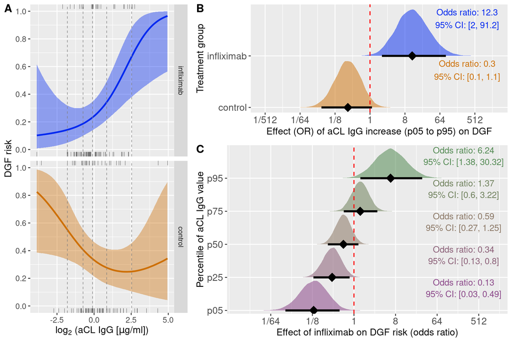

Figure 3: **Anti-cardiolipin IgG modulates infliximab effect on delayed graft function.** (**A**) Predicted DGF risk by anti-cardiolipin IgG for infliximab (upper) and control (lower) groups, with covariates held at their sample means. Shaded regions represent 95% credible intervals; dashed lines indicate the 5th, 25th, 50th, 75th, and 95th percentiles of cardiolipin levels. (**B**) Posterior distribution of the estimated odds ratio comparing DGF odds at the 95th vs. 5th percentile of anti-cardiolipin IgG. (**C**) Posterior distribution of the infliximab effect (odds ratio) on DGF risk across anti-cardiolipin IgG percentiles. Results are from a multivariable Bayesian logistic model with B-splines.

```r
plotac <- 'figure_2'
path <- "gitignore/figures"


fig <- cowplot::plot_grid(fig_b, fig_c,
  rel_heights = c(0.7, 1),
  labels = c("B", "C"),
  ncol = 1
)

assign(
  plotac,
  cowplot::plot_grid(
    fig_a, fig,
    rel_widths = c(0.6, 1),
    labels = c("A", "")
  )
)

get(plotac)

if (file.exists(paste0(path, "/", plotac)) == FALSE) {
  ggsave(
    path = paste0(path),
    filename = plotac,
    device = "pdf",
    width = 9,
    height = 6
  )
}
```

## 7.2 DGF by MPL_BC

### 7.2.1 Priors

#### 7.2.1.1 Main effects model

**Open code**

```r
priors_main <- c(
  create_prior("IMPL_BC_log2M2",
    2 / sd(data_model_priorImpute$MPL_BC_log2, na.rm = TRUE),
    coef = "IMPL_BC_log2M2"
  ),
   create_prior("IHLA_MMM5",
    2 / sd(data_model_priorImpute$HLA_MM, na.rm = TRUE),
    coef = "IHLA_MMM5"
  ),
  create_prior("IKDPIM50",
    2 / sd(data_model_priorImpute$KDPI, na.rm = TRUE),
    coef = "IKDPIM50"
  ),
  create_prior("Irec_ageM50",
    2 / sd(data_model_priorImpute$rec_age, na.rm = TRUE),
    coef = "Irec_ageM50"
),
  create_prior("ICITM15",
    2 / sd(data_model_priorImpute$CIT, na.rm = TRUE),
    coef = "ICITM15"
  ),
  create_prior("male_sex",
    4,
    coef = "male_sex"
  ),
  create_prior("perfusion_event",
    4,
    coef = "perfusion_event"
  ),
  create_prior("male_sex_donor",
    4,
    coef = "male_sex_donor"
  ),
  create_prior("infliximab",
    4,
    coef = "infliximab"
  ),
  set_prior(paste0("normal(", logit(mean(data_model_priorImpute$DGF)), ", 10)"),
    class = "Intercept"
  )
)
```

#### 7.2.1.2 Non-linear penalized interaction model

**Open code**

```r
priors_interaction_pnl <- c(
  create_prior("Irec_ageM50",
               2 / sd(data_model_priorImpute$rec_age, na.rm = TRUE),
               coef = "Irec_ageM50"),
  create_prior("IHLA_MMM5",
               2 / sd(data_model_priorImpute$HLA_MM, na.rm = TRUE),
               coef = "IHLA_MMM5"),
  create_prior("IKDPIM50",
               2 / sd(data_model_priorImpute$KDPI, na.rm = TRUE),
               coef = "IKDPIM50"),
  create_prior("ICITM15",
               2 / sd(data_model_priorImpute$CIT, na.rm = TRUE),
               coef = "ICITM15"),
  create_prior("male_sex",
               4,
               coef = "male_sex"),
  create_prior("perfusion_event",
               4,
               coef = "perfusion_event"),
  create_prior("male_sex_donor",
               4,
               coef = "male_sex_donor"),

  create_prior("infliximab",
               4,
               coef = "infliximab"),

 set_prior("student_t(3, 0, 0.6)", class = "sds",
           coef = 's(I(MPL_BC_log2 - 2), bs = "ps", k = 5)'),

 set_prior("student_t(3, 0, 0.3)", class = "sds",
           coef = 's(I(MPL_BC_log2 - 2), by = infliximab, bs = "ps", k = 5)'),

  set_prior(paste0("normal(", logit(mean(data_model_priorImpute$DGF)), ", 10)"),
            class = "Intercept")
)
```

### 7.2.2 Models

#### 7.2.2.1 Main effects models

**Open code**

```r
set.seed(2025)
model_dgf_MPL_BC_main <- run(
  expr = brm_multiple(
    DGF ~
      male_sex +
      I(rec_age - 50) +
      male_sex_donor +
      I(KDPI - 50) +
      I(CIT - 15) +
      I(HLA_MM - 5) +
      perfusion_event +
      infliximab +
      I(MPL_BC_log2 - 2),
    family = bernoulli(),
    data = data_imputed,
    prior = priors_main,
    backend = "cmdstanr",
    seed = 2025,
    cores = 4, chains = 4,
    iter = 2000, warmup = 1900,
    control = list(adapt_delta = 0.95)
  ),
  path = "gitignore/run/model_dgf_MPL_BC_main",
  reuse = TRUE
)

summary(model_dgf_MPL_BC_main, robust = TRUE)
## Warning: Parts of the model have not converged (some Rhats are > 1.05). Be
## careful when analysing the results! We recommend running more iterations and/or
## setting stronger priors.
##  Family: bernoulli
##   Links: mu = logit
## Formula: DGF ~ male_sex + I(rec_age - 50) + male_sex_donor + I(KDPI - 50) + I(CIT - 15) + I(HLA_MM - 5) + perfusion_event + infliximab + I(MPL_BC_log2 - 2)
##    Data: data_imputed (Number of observations: 177)
##   Draws: 320 chains, each with iter = 2000; warmup = 1900; thin = 1;
##          total post-warmup draws = 32000
##
## Regression Coefficients:
##                 Estimate Est.Error l-95% CI u-95% CI Rhat Bulk_ESS Tail_ESS
## Intercept          -0.88      0.48    -1.85     0.05 1.02    14414    25568
## male_sex            0.89      0.39     0.14     1.69 1.01    35387    28013
## Irec_ageM50        -0.02      0.02    -0.06     0.01 1.01    37218    27652
## male_sex_donor      0.14      0.37    -0.59     0.87 1.01    36459    27773
## IKDPIM50            0.01      0.01    -0.01     0.02 1.01    36554    27839
## ICITM15             0.07      0.03     0.02     0.13 1.02    11114    26679
## IHLA_MMM5           0.25      0.13    -0.00     0.52 1.06     3433    12047
## perfusion_event    -0.61      0.41    -1.45     0.19 1.07     3180    11578
## infliximab         -0.24      0.36    -0.97     0.48 1.01    35927    27005
## IMPL_BC_log2M2      0.20      0.12    -0.04     0.44 1.01    35829    26440
##
## Draws were sampled using sample(hmc). For each parameter, Bulk_ESS
## and Tail_ESS are effective sample size measures, and Rhat is the potential
## scale reduction factor on split chains (at convergence, Rhat = 1).
prior_summary(model_dgf_MPL_BC_main)
##                           prior     class            coef group resp dpar nlpar
##                          (flat)         b
##    normal(0, 0.280307006032291)         b         ICITM15
##     normal(0, 1.38219051128263)         b       IHLA_MMM5
##   normal(0, 0.0970980394231448)         b        IKDPIM50
##     normal(0, 1.27934317633706)         b  IMPL_BC_log2M2
##                    normal(0, 4)         b      infliximab
##    normal(0, 0.190589762164436)         b     Irec_ageM50
##                    normal(0, 4)         b        male_sex
##                    normal(0, 4)         b  male_sex_donor
##                    normal(0, 4)         b perfusion_event
##  normal(-0.667829372575656, 10) Intercept
##  lb ub  source
##        default
##           user
##           user
##           user
##           user
##           user
##           user
##           user
##           user
##           user
##           user

tr <- round(exp(fixef(model_dgf_MPL_BC_main, robust = TRUE)[-1, c(1,3,4)]), 2)
colnames(tr)[1] <- 'OR'
kableExtra::kable(tr)
```

Table 11: Results from multivariable Bayesian logistic regression models examining the main effects of predictors, including `infliximab` treatment and log2-transformed anti-cardiolipin IgM (`MPL_BC_log2`), on delayed graft function (`DGF`), without interaction terms. The odds ratio (OR) represents the estimated change in the odds of DGF per one-unit increase in the predictor. `OR`: odds ratio; `Q2.5` and `Q97.5`: lower and upper bounds of the 95% credible interval, respectively.

|  | OR | Q2.5 | Q97.5 |
| --- | --- | --- | --- |
| male_sex | 2.44 | 1.15 | 5.40 |
| Irec_ageM50 | 0.98 | 0.95 | 1.01 |
| male_sex_donor | 1.15 | 0.56 | 2.40 |
| IKDPIM50 | 1.01 | 0.99 | 1.02 |
| ICITM15 | 1.08 | 1.02 | 1.14 |
| IHLA_MMM5 | 1.28 | 1.00 | 1.69 |
| perfusion_event | 0.55 | 0.23 | 1.21 |
| infliximab | 0.79 | 0.38 | 1.61 |
| IMPL_BC_log2M2 | 1.22 | 0.96 | 1.56 |